# Trait synergies

Exploration of the trait analysis for trait synchrony.

Parameters: environmental correction is TRUE.

## Hypotheses

Check all hypotheses between traits and environmental drivers, and among traits

## Big PCA

Trait_short

Expected_direction

Direct/indirect

Disturbance

ref_dist

Resources

ref_res

Est

CI

Padj

Fit_exp

Mowing

Grazing

Fertil

Est_nocorr

CI_nocorr

Fit_exp_nocorr

**Arthropods (above, herbivores)**

SLA

++

D

- disturbance favours fast-growing species

NA

- more nutrients allow for ‘cheap’ leaves

NA

0.35

0.2 - 0.5

0.0000313

✅

0.36

0.13

0.10

0.35

0.2 - 0.5

✅

Seed_mass

–

D

- disturbance selects for smaller seeds (= colonisation)

Diaz et al. 2016

NA

NA

-0.37

-0.52 - -0.22

0.0000000

✅

-0.16

-0.21

-0.28

-0.29

-0.45 - -0.14

✅

LDMC

–

D

Tougher = slow

NA

NA

NA

-0.38

-0.53 - -0.23

0.0000000

✅

-0.40

-0.43

-0.02

-0.36

-0.51 - -0.21

✅

LeafN

++

D

NA

NA

- more nutrients allow for ‘cheap’ leaves

Diaz et al. 2016

0.49

0.35 - 0.63

0.0000000

✅

0.38

0.46

0.14

0.48

0.34 - 0.62

✅

**Arthropods (above, omnicarnivores)**

LeafP

++

D

NA

NA

- more nutrients allow for ‘cheap’ leaves

NA

0.56

0.42 - 0.69

0.0000000

✅

0.34

0.45

0.26

0.53

0.39 - 0.66

✅

Root_tissue_density

–

D

NA

NA

- conservative and/or ‘collaboration’ => if few nutrients, need for collaboration

Bergmann et al. 2020

-0.22

-0.38 - -0.06

0.0119654

✅

-0.26

-0.06

-0.04

-0.27

-0.42 - -0.11

✅

**Arthropods (below, herbivores)**

Aoc_BodySize

–

D

Smaller species evade disturbance more easily

Birkhofer et al. 2015, 2017, see also Blake 1994, Neff et al. 2019, Simons et al. 2016

NA

NA

0.05

-0.11 - 0.21

0.6465438

Inconclusive

0.04

-0.23

0.07

0.08

-0.08 - 0.25

Inconclusive

Aoc_Dispersal

++

D

Disturbance selects for good dispersers to recolonize the plot after disturbance, Hanson et al. 2016

Birkhofer et al. 2013, 2015, 2017 , Simons et al. 2016

NA

NA

0.33

0.18 - 0.48

0.0001175

✅

0.53

0.23

-0.12

0.32

0.17 - 0.48

✅

Ah_BodySize

+/-

D

Smaller species evade disturbance more easily

Birkhofer et al. 2015, 2017, see also Blake 1994, Neff et al. 2019, Simons et al. 2016

NA

NA

-0.24

-0.39 - -0.08

0.0074773

B

-0.30

-0.29

0.02

-0.26

-0.42 - -0.1

B

**Arthropods (below, predators)**

Ah_Dispersal

++

D

Disturbance selects for good dispersers to recolonize the plot after disturbance, Hanson et al. 2016

Birkhofer et al. 2013, 2015, 2017 , Simons et al. 2016

NA

NA

0.44

0.29 - 0.58

0.0000000

✅

0.24

0.40

0.24

0.28

0.13 - 0.44

✅

Ah_Generalism

++

NA

NA

NA

NA

NA

0.38

0.23 - 0.53

0.0000000

✅

0.04

0.31

0.31

0.39

0.24 - 0.54

✅

**Bats**

Ah_Generations

++

I

NA

NA

NA

NA

0.61

0.49 - 0.74

0.0000000

✅

0.61

0.39

0.15

0.54

0.4 - 0.68

✅

Aoc_b_BodySize

–

D

Smaller species evade disturbance more easily

Birkhofer et al. 2015, 2017, see also Blake 1994, Neff et al. 2019, Simons et al. 2016

NA

NA

-0.05

-0.21 - 0.11

0.6465438

Inconclusive

-0.08

-0.02

0.03

-0.01

-0.17 - 0.15

Inconclusive

Aoc_b_Dispersal

++

D

Disturbance selects for good dispersers to recolonize the plot after disturbance, Hanson et al. 2016

Birkhofer et al. 2013, 2015, 2017 , Simons et al. 2016

NA

NA

0.10

-0.06 - 0.26

0.3099788

Inconclusive

0.20

0.05

-0.04

0.11

-0.05 - 0.27

Inconclusive

**Birds (insectivorous)**

Ah_b_BodySize

–

D

Smaller species evade disturbance more easily

Birkhofer et al. 2015, 2017, see also Blake 1994, Neff et al. 2019, Simons et al. 2016

NA

NA

-0.28

-0.46 - -0.1

0.0060429

✅

-0.24

-0.32

-0.03

-0.25

-0.41 - -0.09

✅

Ah_b_Dispersal

++

D

Disturbance selects for good dispersers to recolonize the plot after disturbance, Hanson et al. 2016

Birkhofer et al. 2013, 2015, 2017 , Simons et al. 2016

NA

NA

0.18

-0.01 - 0.36

0.1060903

Inconclusive

-0.04

0.08

0.25

0.15

-0.01 - 0.32

Inconclusive

Ah_b_Generalism

++

NA

NA

NA

NA

NA

-0.02

-0.2 - 0.17

0.8792400

Inconclusive

0.11

0.06

-0.16

-0.09

-0.28 - 0.1

Inconclusive

Bi_Size

++

NA

more = fast

NA

NA

NA

0.26

0.1 - 0.42

0.0031663

✅

0.33

0.20

0.01

0.31

0.16 - 0.47

✅

Bi_Incub

++

NA

more = disturbance

NA

NA

NA

0.14

-0.02 - 0.3

0.1459274

Inconclusive

0.30

0.12

-0.09

0.18

0.02 - 0.34

✔

**Butterflies**

Bi_TOffsprings

–

I

Small = fast

NA

NA

NA

-0.14

-0.3 - 0.02

0.1449167

Inconclusive

-0.33

-0.14

0.12

-0.15

-0.31 - 0.01

Inconclusive

Bi_GenLength

–

NA

NA

NA

NA

NA

0.22

0.06 - 0.38

0.0133480

❌

0.34

0.19

-0.05

0.27

0.11 - 0.42

❌

Bi_AgeMax

–

I

Small = fast

NA

NA

NA

0.26

0.1 - 0.41

0.0042065

❌

0.31

0.21

0.00

0.30

0.15 - 0.46

❌

but_flight

++

NA

Early emergence favorable bc disturbance starts early

Börschig et al. 2013

NA

NA

0.41

0.27 - 0.56

0.0000000

✅

0.53

0.25

0.05

0.25

0.09 - 0.41

✅

but_GenYear

++

NA

High reproduction can compensate mortality due to disturbance

Börschig et al. 2013

NA

NA

0.19

0.02 - 0.35

0.0429267

✅

0.11

0.12

0.08

0.23

0.07 - 0.39

✅

**Collembola**

but_hibernation

++

NA

Later hibernation stage means butterflies ready before disturbance

NA

NA

NA

0.38

0.23 - 0.53

0.0000000

✅

0.41

0.24

0.09

0.25

0.09 - 0.41

✅

but_Size

++

NA

Larger wings = more dispersal

Börschig et al. 2013

NA

NA

-0.03

-0.2 - 0.13

0.7896000

Inconclusive

-0.05

-0.06

0.03

-0.13

-0.29 - 0.03

Inconclusive

but_Generalism

++

NA

NA

NA

High nutrients = low plant diversity, hence more generalists

NA

0.27

0.11 - 0.43

0.0024022

✅

0.07

0.03

0.24

0.28

0.12 - 0.44

✅

col_Sex

–

NA

NA

NA

NA

NA

0.01

-0.16 - 0.18

0.8792400

Inconclusive

-0.02

0.06

0.03

0.01

-0.16 - 0.17

Inconclusive

**Microbes**

col_Gen_per_Year

++

NA

Furca = escape disturbance

NA

NA

NA

-0.11

-0.27 - 0.06

0.3099788

Inconclusive

0.23

-0.07

-0.30

-0.09

-0.26 - 0.08

Inconclusive

col_Depth

++

NA

NA

NA

NA

NA

-0.03

-0.2 - 0.14

0.7932959

Inconclusive

0.00

-0.13

-0.01

-0.01

-0.18 - 0.16

Inconclusive

col_Size

–

NA

a/ more resources or b/ selected

NA

NA

NA

0.05

-0.12 - 0.22

0.6465438

Inconclusive

-0.22

0.00

0.24

0.04

-0.13 - 0.21

Inconclusive

mites_DaysAdult

–

NA

longer lifespan = slow

NA

NA

NA

-0.06

-0.23 - 0.11

0.6075830

Inconclusive

-0.10

-0.16

0.05

-0.05

-0.22 - 0.12

Inconclusive

mites_Mass

–

NA

Mass = size = slow

NA

NA

NA

-0.17

-0.34 - -0.01

0.0730850

✔

-0.09

-0.21

-0.09

-0.16

-0.32 - 0.01

Inconclusive

**Mites**

mites_Sex

–

I

Habitat openness = sexual repro, more LUI = more growth

NA

NA

NA

0.02

-0.15 - 0.19

0.8569040

Inconclusive

0.09

-0.02

-0.06

0.01

-0.16 - 0.18

Inconclusive

mites_Hab_spec

++

NA

more disturbance = more in the soil

NA

NA

NA

-0.04

-0.21 - 0.13

0.7023176

Inconclusive

-0.18

-0.09

0.10

-0.03

-0.2 - 0.14

Inconclusive

mites_Feed_spec

++

NA

NA

NA

NA

NA

0.10

-0.06 - 0.27

0.3099788

Inconclusive

0.14

0.08

-0.01

0.12

-0.04 - 0.29

Inconclusive

P_patho

++

NA

More bacteria = more bacterivores

NA

NA

NA

0.49

0.35 - 0.63

0.0000000

✅

0.33

0.37

0.21

0.46

0.32 - 0.61

✅

Pb_Size

–

NA

a/ More nutrients = more resources to grow. b/ Disturbance selects smaller size

NA

NA

NA

-0.20

-0.36 - -0.04

0.0266815

✅

-0.36

-0.13

0.03

-0.27

-0.43 - -0.11

✅

**Plants (AG)**

Ps_Size

–

NA

a/ More nutrients = more resources to grow. b/ Disturbance selects smaller size

NA

NA

NA

-0.44

-0.58 - -0.29

0.0000000

✅

-0.11

-0.39

-0.31

-0.31

-0.46 - -0.15

✅

mic_FB

–

D and I

Fungi slower than bacteria, linked to slow plant traits

NA

Fungi dominate in low-nutrient soils; associated with slow plants

de Vries et al. 2006, de Vries et al. 2012, Boeddinghaus et al. 2019

-0.37

-0.52 - -0.22

0.0000000

✅

-0.22

-0.37

-0.18

-0.24

-0.4 - -0.08

✅

mic_Fpathotroph

++

NA

Fast= more parasites

check https://www.nature.com/articles/s41467-021-23605-y

Fast plant invest less in defenses, so more pathogens

NA

0.42

0.27 - 0.56

0.0000000

✅

0.19

0.47

0.22

0.31

0.15 - 0.46

✅

mic_O.C.ratio

–

NA

NA

NA

- more oligo (Acido) than copio (Actibo, alphapto…) in slow

Check Neff 2015, Ramirez 2010, Fierer 2012

-0.23

-0.38 - -0.07

0.0114230

✅

0.09

-0.14

-0.27

-0.04

-0.2 - 0.12

Inconclusive

mic_Bvolume

+/-

D

a/ small cells more efficient for diffusive uptake (-) OR b/ for a given substrate demand, large radius compensates low substrate concentrations

Westoby et al. 2021

NA

NA

-0.45

-0.59 - -0.3

0.0000000

B

-0.19

-0.31

-0.28

-0.31

-0.46 - -0.15

B

**Plants (BG)**

mic_Bgenome_size

–

D

NA

NA

- Larger genomes should be more successful in resource-poor environments v. S strategies have smaller genomes (Westoby et al.)

Leff et al. 2015; Konstantinidis (2004)

-0.30

-0.46 - -0.15

0.0004147

✅

-0.11

-0.42

-0.13

-0.04

-0.21 - 0.12

Inconclusive

**Protists**

bat_mass

–

NA

Large more sensitive to disturbance BUT large less sensitive to urbanisation??

Farneda et al. 2015, Moir et al. 2021 , Jung et al 2018

NA

NA

-0.10

-0.26 - 0.06

0.3160146

Inconclusive

-0.07

-0.04

-0.05

-0.17

-0.33 - -0.01

✔

**Protists bacterivores**

bat_lifespan

NA

NA

NA

NA

NA

NA

-0.03

-0.19 - 0.14

0.7932959

Inconclusive

0.11

-0.13

-0.09

0.06

-0.1 - 0.23

Inconclusive

**Protists predators**

bat_offspring

++

NA

opposite to size

NA

NA

NA

-0.06

-0.22 - 0.1

0.5947589

Inconclusive

-0.09

0.12

-0.03

-0.16

-0.32 - 0.01

Inconclusive

## Identification of strategy axes for each group

### Plants, above- and below-ground

Trait_short

Expected_direction

Direct/indirect

Disturbance

ref_dist

Resources

ref_res

Est

CI

Padj

Fit_exp

Mowing

Grazing

Fertil

Est_nocorr

CI_nocorr

Fit_exp_nocorr

**Plants (AG)**

SLA

++

D

- disturbance favours fast-growing species

NA

- more nutrients allow for ‘cheap’ leaves

NA

0.35

0.2 - 0.5

0.0000313

✅

0.36

0.13

0.10

0.35

0.2 - 0.5

✅

Seed_mass

–

D

- disturbance selects for smaller seeds (= colonisation)

Diaz et al. 2016

NA

NA

-0.37

-0.52 - -0.22

0.0000000

✅

-0.16

-0.21

-0.28

-0.29

-0.45 - -0.14

✅

LDMC

–

D

Tougher = slow

NA

NA

NA

-0.38

-0.53 - -0.23

0.0000000

✅

-0.40

-0.43

-0.02

-0.36

-0.51 - -0.21

✅

LeafN

++

D

NA

NA

- more nutrients allow for ‘cheap’ leaves

Diaz et al. 2016

0.49

0.35 - 0.63

0.0000000

✅

0.38

0.46

0.14

0.48

0.34 - 0.62

✅

LeafP

++

D

NA

NA

- more nutrients allow for ‘cheap’ leaves

NA

0.56

0.42 - 0.69

0.0000000

✅

0.34

0.45

0.26

0.53

0.39 - 0.66

✅

**Plants (BG)**

Root_tissue_density

–

D

NA

NA

- conservative and/or ‘collaboration’ => if few nutrients, need for collaboration

Bergmann et al. 2020

-0.22

-0.38 - -0.06

0.0119654

✅

-0.26

-0.06

-0.04

-0.27

-0.42 - -0.11

✅

```
## [1] "Plants, All"
```

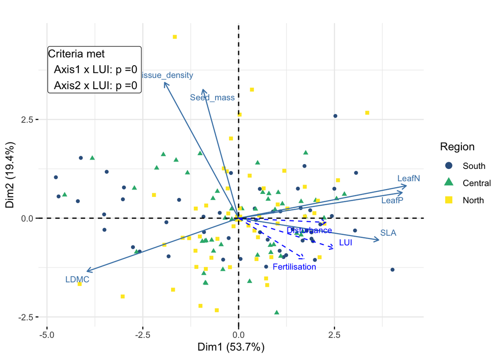

## Bacteria & fungi

Trait_short

Expected_direction

Direct/indirect

Disturbance

ref_dist

Resources

ref_res

Est

CI

Padj

Fit_exp

Mowing

Grazing

Fertil

Est_nocorr

CI_nocorr

Fit_exp_nocorr

**Microbes**

mic_FB

–

D and I

Fungi slower than bacteria, linked to slow plant traits

NA

Fungi dominate in low-nutrient soils; associated with slow plants

de Vries et al. 2006, de Vries et al. 2012, Boeddinghaus et al. 2019

-0.37

-0.52 - -0.22

0.0000000

✅

-0.22

-0.37

-0.18

-0.24

-0.4 - -0.08

✅

mic_Fpathotroph

++

NA

Fast= more parasites

check https://www.nature.com/articles/s41467-021-23605-y

Fast plant invest less in defenses, so more pathogens

NA

0.42

0.27 - 0.56

0.0000000

✅

0.19

0.47

0.22

0.31

0.15 - 0.46

✅

mic_O.C.ratio

–

NA

NA

NA

- more oligo (Acido) than copio (Actibo, alphapto…) in slow

Check Neff 2015, Ramirez 2010, Fierer 2012

-0.23

-0.38 - -0.07

0.0114230

✅

0.09

-0.14

-0.27

-0.04

-0.2 - 0.12

Inconclusive

mic_Bvolume

+/-

D

a/ small cells more efficient for diffusive uptake (-) OR b/ for a given substrate demand, large radius compensates low substrate concentrations

Westoby et al. 2021

NA

NA

-0.45

-0.59 - -0.3

0.0000000

B

-0.19

-0.31

-0.28

-0.31

-0.46 - -0.15

B

mic_Bgenome_size

–

D

NA

NA

- Larger genomes should be more successful in resource-poor environments v. S strategies have smaller genomes (Westoby et al.)

Leff et al. 2015; Konstantinidis (2004)

-0.30

-0.46 - -0.15

0.0004147

✅

-0.11

-0.42

-0.13

-0.04

-0.21 - 0.12

Inconclusive

## Arthropods, above-ground

### Herbivores

| Trait_short | Expected_direction | Direct/indirect | Disturbance | ref_dist | Resources | ref_res | Est | CI | Padj | Fit_exp | Mowing | Grazing | Fertil | Est_nocorr | CI_nocorr | Fit_exp_nocorr |
| --- | --- | --- | --- | --- | --- | --- | --- | --- | --- | --- | --- | --- | --- | --- | --- | --- |
| **Arthropods (above, herbivores)** |  |  |  |  |  |  |  |  |  |  |  |  |  |  |  |  |
| Aoc_BodySize | – | D | Smaller species evade disturbance more easily | Birkhofer et al. 2015, 2017, see also Blake 1994, Neff et al. 2019, Simons et al. 2016 | NA | NA | 0.05 | -0.11 - 0.21 | 0.6465438 | Inconclusive | 0.04 | -0.23 | 0.07 | 0.08 | -0.08 - 0.25 | Inconclusive |
| Aoc_Dispersal | ++ | D | Disturbance selects for good dispersers to recolonize the plot after disturbance, Hanson et al. 2016 | Birkhofer et al. 2013, 2015, 2017 , Simons et al. 2016 | NA | NA | 0.33 | 0.18 - 0.48 | 0.0001175 | ✅ | 0.53 | 0.23 | -0.12 | 0.32 | 0.17 - 0.48 | ✅ |
| Ah_BodySize | +/- | D | Smaller species evade disturbance more easily | Birkhofer et al. 2015, 2017, see also Blake 1994, Neff et al. 2019, Simons et al. 2016 | NA | NA | -0.24 | -0.39 - -0.08 | 0.0074773 | B | -0.30 | -0.29 | 0.02 | -0.26 | -0.42 - -0.1 | B |
| Ah_Dispersal | ++ | D | Disturbance selects for good dispersers to recolonize the plot after disturbance, Hanson et al. 2016 | Birkhofer et al. 2013, 2015, 2017 , Simons et al. 2016 | NA | NA | 0.44 | 0.29 - 0.58 | 0.0000000 | ✅ | 0.24 | 0.40 | 0.24 | 0.28 | 0.13 - 0.44 | ✅ |
| **Arthropods (above, omnicarnivores)** |  |  |  |  |  |  |  |  |  |  |  |  |  |  |  |  |
| Ah_Generalism | ++ | NA | NA | NA | NA | NA | 0.38 | 0.23 - 0.53 | 0.0000000 | ✅ | 0.04 | 0.31 | 0.31 | 0.39 | 0.24 - 0.54 | ✅ |
| Ah_Generations | ++ | I | NA | NA | NA | NA | 0.61 | 0.49 - 0.74 | 0.0000000 | ✅ | 0.61 | 0.39 | 0.15 | 0.54 | 0.4 - 0.68 | ✅ |
| **Arthropods (below, herbivores)** |  |  |  |  |  |  |  |  |  |  |  |  |  |  |  |  |
| Aoc_b_BodySize | – | D | Smaller species evade disturbance more easily | Birkhofer et al. 2015, 2017, see also Blake 1994, Neff et al. 2019, Simons et al. 2016 | NA | NA | -0.05 | -0.21 - 0.11 | 0.6465438 | Inconclusive | -0.08 | -0.02 | 0.03 | -0.01 | -0.17 - 0.15 | Inconclusive |
| Aoc_b_Dispersal | ++ | D | Disturbance selects for good dispersers to recolonize the plot after disturbance, Hanson et al. 2016 | Birkhofer et al. 2013, 2015, 2017 , Simons et al. 2016 | NA | NA | 0.10 | -0.06 - 0.26 | 0.3099788 | Inconclusive | 0.20 | 0.05 | -0.04 | 0.11 | -0.05 - 0.27 | Inconclusive |
| Ah_b_BodySize | – | D | Smaller species evade disturbance more easily | Birkhofer et al. 2015, 2017, see also Blake 1994, Neff et al. 2019, Simons et al. 2016 | NA | NA | -0.28 | -0.46 - -0.1 | 0.0060429 | ✅ | -0.24 | -0.32 | -0.03 | -0.25 | -0.41 - -0.09 | ✅ |
| **Arthropods (below, predators)** |  |  |  |  |  |  |  |  |  |  |  |  |  |  |  |  |
| Ah_b_Dispersal | ++ | D | Disturbance selects for good dispersers to recolonize the plot after disturbance, Hanson et al. 2016 | Birkhofer et al. 2013, 2015, 2017 , Simons et al. 2016 | NA | NA | 0.18 | -0.01 - 0.36 | 0.1060903 | Inconclusive | -0.04 | 0.08 | 0.25 | 0.15 | -0.01 - 0.32 | Inconclusive |
| Ah_b_Generalism | ++ | NA | NA | NA | NA | NA | -0.02 | -0.2 - 0.17 | 0.8792400 | Inconclusive | 0.11 | 0.06 | -0.16 | -0.09 | -0.28 - 0.1 | Inconclusive |

| Trait_short | Expected_direction | Direct/indirect | Disturbance | ref_dist | Resources | ref_res | Est | CI | Padj | Fit_exp | Mowing | Grazing | Fertil | Est_nocorr | CI_nocorr | Fit_exp_nocorr |
| --- | --- | --- | --- | --- | --- | --- | --- | --- | --- | --- | --- | --- | --- | --- | --- | --- |
| **Butterflies** |  |  |  |  |  |  |  |  |  |  |  |  |  |  |  |  |
| but_flight | ++ | NA | Early emergence favorable bc disturbance starts early | Börschig et al. 2013 | NA | NA | 0.41 | 0.27 - 0.56 | 0.0000000 | ✅ | 0.53 | 0.25 | 0.05 | 0.25 | 0.09 - 0.41 | ✅ |
| but_GenYear | ++ | NA | High reproduction can compensate mortality due to disturbance | Börschig et al. 2013 | NA | NA | 0.19 | 0.02 - 0.35 | 0.0429267 | ✅ | 0.11 | 0.12 | 0.08 | 0.23 | 0.07 - 0.39 | ✅ |
| but_hibernation | ++ | NA | Later hibernation stage means butterflies ready before disturbance | NA | NA | NA | 0.38 | 0.23 - 0.53 | 0.0000000 | ✅ | 0.41 | 0.24 | 0.09 | 0.25 | 0.09 - 0.41 | ✅ |
| but_Size | ++ | NA | Larger wings = more dispersal | Börschig et al. 2013 | NA | NA | -0.03 | -0.2 - 0.13 | 0.7896000 | Inconclusive | -0.05 | -0.06 | 0.03 | -0.13 | -0.29 - 0.03 | Inconclusive |
| but_Generalism | ++ | NA | NA | NA | High nutrients = low plant diversity, hence more generalists | NA | 0.27 | 0.11 - 0.43 | 0.0024022 | ✅ | 0.07 | 0.03 | 0.24 | 0.28 | 0.12 - 0.44 | ✅ |

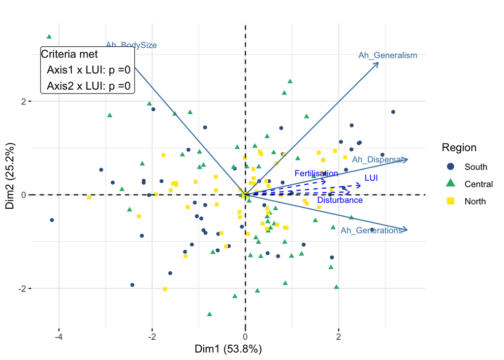

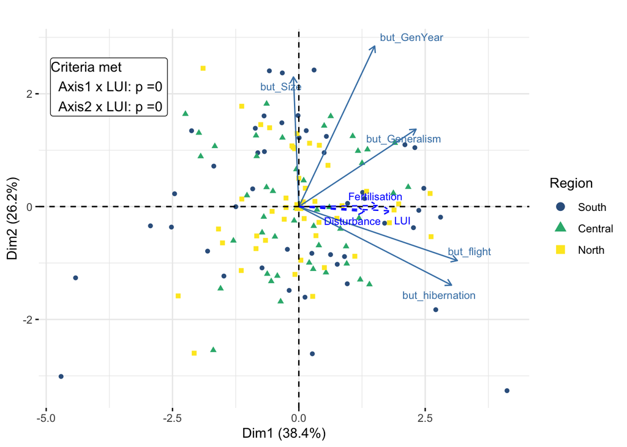

### Predators

| Trait_short | Expected_direction | Direct/indirect | Disturbance | ref_dist | Resources | ref_res | Est | CI | Padj | Fit_exp | Mowing | Grazing | Fertil | Est_nocorr | CI_nocorr | Fit_exp_nocorr |
| --- | --- | --- | --- | --- | --- | --- | --- | --- | --- | --- | --- | --- | --- | --- | --- | --- |
| **Arthropods (above, omnicarnivores)** |  |  |  |  |  |  |  |  |  |  |  |  |  |  |  |  |
| Aoc_BodySize | – | D | Smaller species evade disturbance more easily | Birkhofer et al. 2015, 2017, see also Blake 1994, Neff et al. 2019, Simons et al. 2016 | NA | NA | 0.05 | -0.11 - 0.21 | 0.6465438 | Inconclusive | 0.04 | -0.23 | 0.07 | 0.08 | -0.08 - 0.25 | Inconclusive |
| Aoc_Dispersal | ++ | D | Disturbance selects for good dispersers to recolonize the plot after disturbance, Hanson et al. 2016 | Birkhofer et al. 2013, 2015, 2017 , Simons et al. 2016 | NA | NA | 0.33 | 0.18 - 0.48 | 0.0001175 | ✅ | 0.53 | 0.23 | -0.12 | 0.32 | 0.17 - 0.48 | ✅ |
| **Arthropods (below, predators)** |  |  |  |  |  |  |  |  |  |  |  |  |  |  |  |  |
| Aoc_b_BodySize | – | D | Smaller species evade disturbance more easily | Birkhofer et al. 2015, 2017, see also Blake 1994, Neff et al. 2019, Simons et al. 2016 | NA | NA | -0.05 | -0.21 - 0.11 | 0.6465438 | Inconclusive | -0.08 | -0.02 | 0.03 | -0.01 | -0.17 - 0.15 | Inconclusive |
| Aoc_b_Dispersal | ++ | D | Disturbance selects for good dispersers to recolonize the plot after disturbance, Hanson et al. 2016 | Birkhofer et al. 2013, 2015, 2017 , Simons et al. 2016 | NA | NA | 0.10 | -0.06 - 0.26 | 0.3099788 | Inconclusive | 0.20 | 0.05 | -0.04 | 0.11 | -0.05 - 0.27 | Inconclusive |

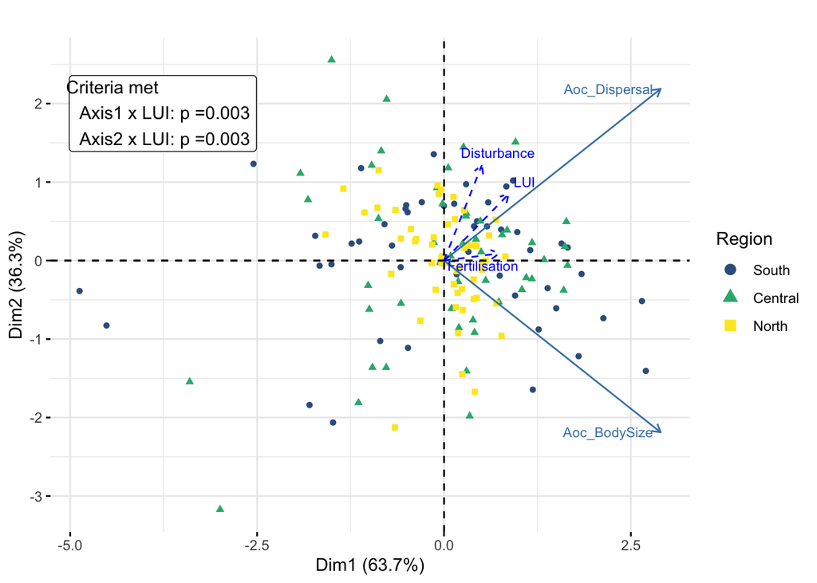

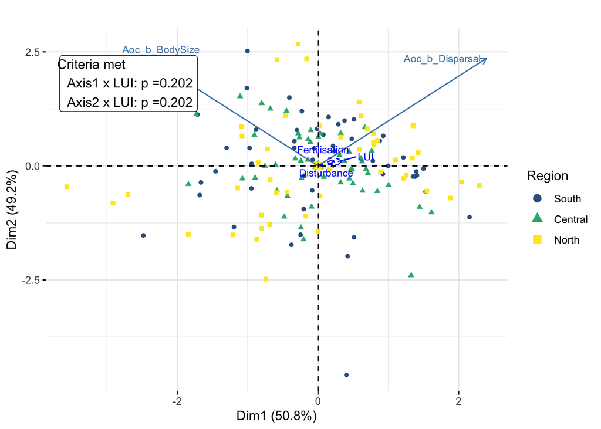

### Protists

| Trait_short | Expected_direction | Direct/indirect | Disturbance | ref_dist | Resources | ref_res | Est | CI | Padj | Fit_exp | Mowing | Grazing | Fertil | Est_nocorr | CI_nocorr | Fit_exp_nocorr |
| --- | --- | --- | --- | --- | --- | --- | --- | --- | --- | --- | --- | --- | --- | --- | --- | --- |
| **Protists** |  |  |  |  |  |  |  |  |  |  |  |  |  |  |  |  |
| P_patho | ++ | NA | More bacteria = more bacterivores | NA | NA | NA | 0.49 | 0.35 - 0.63 | 0.0000000 | ✅ | 0.33 | 0.37 | 0.21 | 0.46 | 0.32 - 0.61 | ✅ |
| **Protists bacterivores** |  |  |  |  |  |  |  |  |  |  |  |  |  |  |  |  |
| Pb_Size | – | NA | a/ More nutrients = more resources to grow. b/ Disturbance selects smaller size | NA | NA | NA | -0.20 | -0.36 - -0.04 | 0.0266815 | ✅ | -0.36 | -0.13 | 0.03 | -0.27 | -0.43 - -0.11 | ✅ |
| **Protists predators** |  |  |  |  |  |  |  |  |  |  |  |  |  |  |  |  |
| Ps_Size | – | NA | a/ More nutrients = more resources to grow. b/ Disturbance selects smaller size | NA | NA | NA | -0.44 | -0.58 - -0.29 | 0.0000000 | ✅ | -0.11 | -0.39 | -0.31 | -0.31 | -0.46 - -0.15 | ✅ |

## Birds

| Trait_short | Expected_direction | Direct/indirect | Disturbance | ref_dist | Resources | ref_res | Est | CI | Padj | Fit_exp | Mowing | Grazing | Fertil | Est_nocorr | CI_nocorr | Fit_exp_nocorr |
| --- | --- | --- | --- | --- | --- | --- | --- | --- | --- | --- | --- | --- | --- | --- | --- | --- |
| **Birds (insectivorous)** |  |  |  |  |  |  |  |  |  |  |  |  |  |  |  |  |
| Bi_Size | ++ | NA | more = fast | NA | NA | NA | 0.26 | 0.1 - 0.42 | 0.0031663 | ✅ | 0.33 | 0.20 | 0.01 | 0.31 | 0.16 - 0.47 | ✅ |
| Bi_Incub | ++ | NA | more = disturbance | NA | NA | NA | 0.14 | -0.02 - 0.3 | 0.1459274 | Inconclusive | 0.30 | 0.12 | -0.09 | 0.18 | 0.02 - 0.34 | ✔ |
| Bi_TOffsprings | – | I | Small = fast | NA | NA | NA | -0.14 | -0.3 - 0.02 | 0.1449167 | Inconclusive | -0.33 | -0.14 | 0.12 | -0.15 | -0.31 - 0.01 | Inconclusive |
| Bi_GenLength | – | NA | NA | NA | NA | NA | 0.22 | 0.06 - 0.38 | 0.0133480 | ❌ | 0.34 | 0.19 | -0.05 | 0.27 | 0.11 - 0.42 | ❌ |
| Bi_AgeMax | – | I | Small = fast | NA | NA | NA | 0.26 | 0.1 - 0.41 | 0.0042065 | ❌ | 0.31 | 0.21 | 0.00 | 0.30 | 0.15 - 0.46 | ❌ |

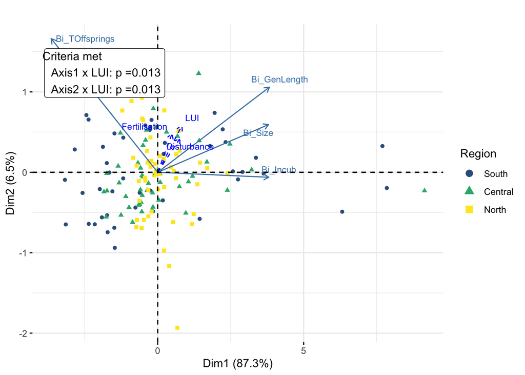

## Mites & collembola

| Trait_short | Expected_direction | Direct/indirect | Disturbance | ref_dist | Resources | ref_res | Est | CI | Padj | Fit_exp | Mowing | Grazing | Fertil | Est_nocorr | CI_nocorr | Fit_exp_nocorr |
| --- | --- | --- | --- | --- | --- | --- | --- | --- | --- | --- | --- | --- | --- | --- | --- | --- |
| **Mites** |  |  |  |  |  |  |  |  |  |  |  |  |  |  |  |  |
| mites_DaysAdult | – | NA | longer lifespan = slow | NA | NA | NA | -0.06 | -0.23 - 0.11 | 0.6075830 | Inconclusive | -0.10 | -0.16 | 0.05 | -0.05 | -0.22 - 0.12 | Inconclusive |
| mites_Mass | – | NA | Mass = size = slow | NA | NA | NA | -0.17 | -0.34 - -0.01 | 0.0730850 | ✔ | -0.09 | -0.21 | -0.09 | -0.16 | -0.32 - 0.01 | Inconclusive |
| mites_Sex | – | I | Habitat openness = sexual repro, more LUI = more growth | NA | NA | NA | 0.02 | -0.15 - 0.19 | 0.8569040 | Inconclusive | 0.09 | -0.02 | -0.06 | 0.01 | -0.16 - 0.18 | Inconclusive |
| mites_Hab_spec | ++ | NA | more disturbance = more in the soil | NA | NA | NA | -0.04 | -0.21 - 0.13 | 0.7023176 | Inconclusive | -0.18 | -0.09 | 0.10 | -0.03 | -0.2 - 0.14 | Inconclusive |
| mites_Feed_spec | ++ | NA | NA | NA | NA | NA | 0.10 | -0.06 - 0.27 | 0.3099788 | Inconclusive | 0.14 | 0.08 | -0.01 | 0.12 | -0.04 - 0.29 | Inconclusive |

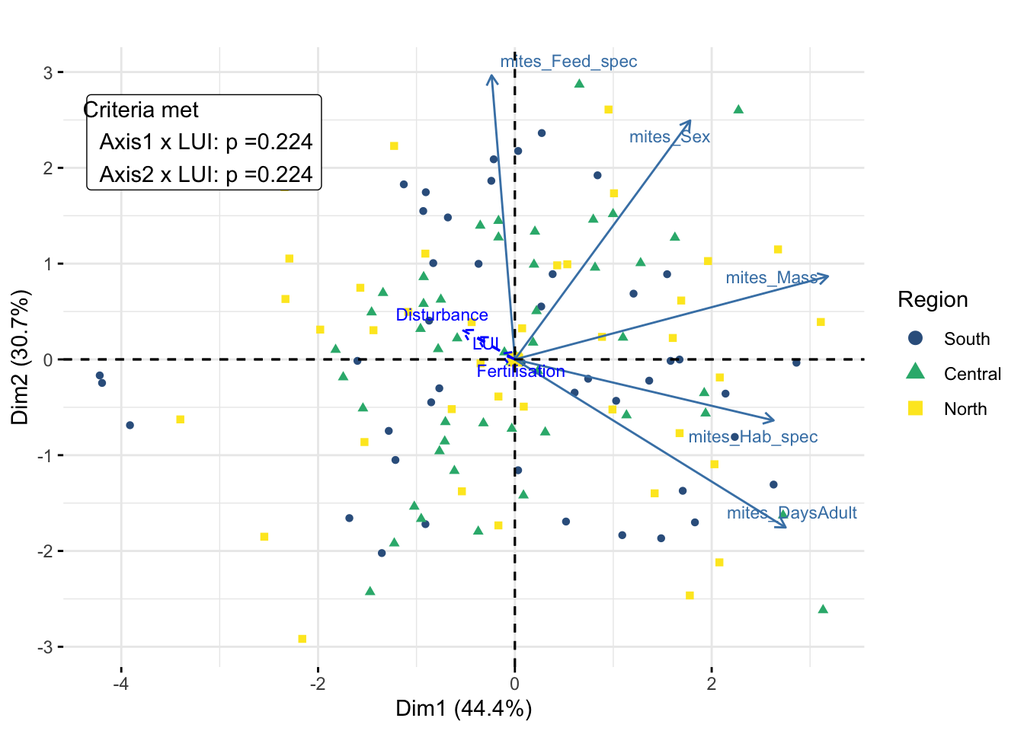

| Trait_short | Expected_direction | Direct/indirect | Disturbance | ref_dist | Resources | ref_res | Est | CI | Padj | Fit_exp | Mowing | Grazing | Fertil | Est_nocorr | CI_nocorr | Fit_exp_nocorr |
| --- | --- | --- | --- | --- | --- | --- | --- | --- | --- | --- | --- | --- | --- | --- | --- | --- |
| **Collembola** |  |  |  |  |  |  |  |  |  |  |  |  |  |  |  |  |
| col_Sex | – | NA | NA | NA | NA | NA | 0.01 | -0.16 - 0.18 | 0.8792400 | Inconclusive | -0.02 | 0.06 | 0.03 | 0.01 | -0.16 - 0.17 | Inconclusive |
| col_Gen_per_Year | ++ | NA | Furca = escape disturbance | NA | NA | NA | -0.11 | -0.27 - 0.06 | 0.3099788 | Inconclusive | 0.23 | -0.07 | -0.30 | -0.09 | -0.26 - 0.08 | Inconclusive |
| col_Depth | ++ | NA | NA | NA | NA | NA | -0.03 | -0.2 - 0.14 | 0.7932959 | Inconclusive | 0.00 | -0.13 | -0.01 | -0.01 | -0.18 - 0.16 | Inconclusive |
| col_Size | – | NA | a/ more resources or b/ selected | NA | NA | NA | 0.05 | -0.12 - 0.22 | 0.6465438 | Inconclusive | -0.22 | 0.00 | 0.24 | 0.04 | -0.13 - 0.21 | Inconclusive |

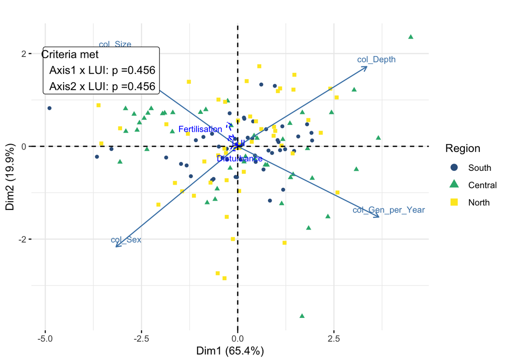

## Bats

| Trait_short | Expected_direction | Direct/indirect | Disturbance | ref_dist | Resources | ref_res | Est | CI | Padj | Fit_exp | Mowing | Grazing | Fertil | Est_nocorr | CI_nocorr | Fit_exp_nocorr |
| --- | --- | --- | --- | --- | --- | --- | --- | --- | --- | --- | --- | --- | --- | --- | --- | --- |
| **Bats** |  |  |  |  |  |  |  |  |  |  |  |  |  |  |  |  |
| bat_mass | – | NA | Large more sensitive to disturbance BUT large less sensitive to urbanisation?? | Farneda et al. 2015, Moir et al. 2021 , Jung et al 2018 | NA | NA | -0.10 | -0.26 - 0.06 | 0.3160146 | Inconclusive | -0.07 | -0.04 | -0.05 | -0.17 | -0.33 - -0.01 | ✔ |
| bat_lifespan | NA | NA | NA | NA | NA | NA | -0.03 | -0.19 - 0.14 | 0.7932959 | Inconclusive | 0.11 | -0.13 | -0.09 | 0.06 | -0.1 - 0.23 | Inconclusive |
| bat_offspring | ++ | NA | opposite to size | NA | NA | NA | -0.06 | -0.22 - 0.1 | 0.5947589 | Inconclusive | -0.09 | 0.12 | -0.03 | -0.16 | -0.32 - 0.01 | Inconclusive |

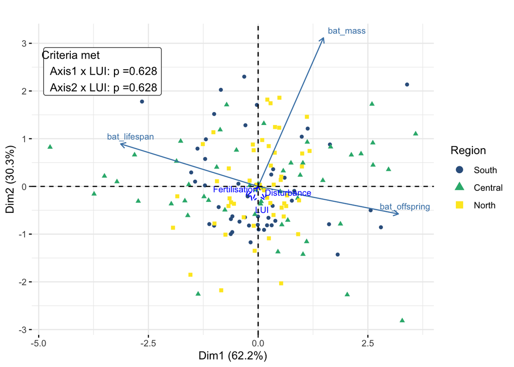

# Try to do a SEM

```
##
##  Pearson's product-moment correlation
##
## data:  PCA_pca$li[, "Axis1"] and env_data_lui[Plot %in% dd$Plot, ]$LUI
## t = 12.614, df = 148, p-value < 2.2e-16
## alternative hypothesis: true correlation is not equal to 0
## 95 percent confidence interval:
##  0.6324707 0.7890214
## sample estimates:
##       cor
## 0.7197753
```

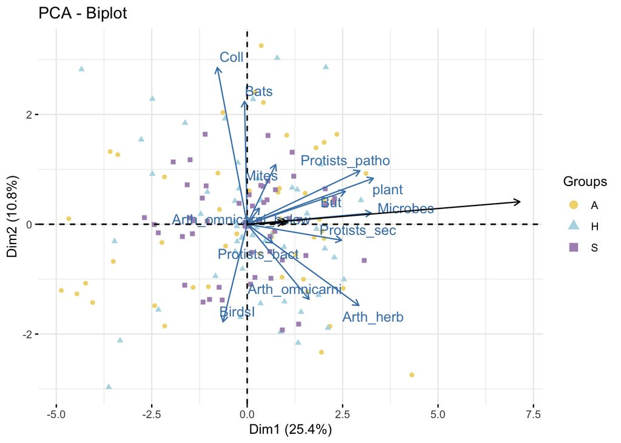

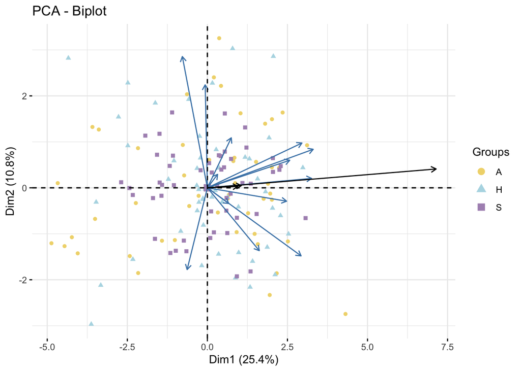

## Run above-ground model, simple

```
## lavaan 0.6-9 ended normally after 21 iterations
##
##   Estimator                                         ML
##   Optimization method                           NLMINB
##   Number of model parameters                        26
##
##                                                   Used       Total
##   Number of observations                           129         150
##
## Model Test User Model:
##
##   Test statistic                                 0.074
##   Degrees of freedom                                 1
##   P-value (Chi-square)                           0.786
##
## Parameter Estimates:
##
##   Standard errors                             Standard
##   Information                                 Expected
##   Information saturated (h1) model          Structured
##
## Regressions:
##                    Estimate  Std.Err  z-value  P(>|z|)   Std.lv  Std.all
##   plant ~
##     LUI               0.540    0.069    7.800    0.000    0.540    0.566
##   Arth_herb ~
##     LUI               0.476    0.077    6.165    0.000    0.476    0.509
##     plant             0.182    0.081    2.252    0.024    0.182    0.186
##   But ~
##     LUI               0.304    0.082    3.719    0.000    0.304    0.334
##     plant             0.267    0.086    3.117    0.002    0.267    0.280
##   Arth_omnicarni ~
##     LUI               0.065    0.116    0.563    0.574    0.065    0.067
##     plant            -0.005    0.109   -0.042    0.967   -0.005   -0.004
##     But               0.105    0.106    0.992    0.321    0.105    0.098
##     Arth_herb         0.252    0.112    2.252    0.024    0.252    0.241
##   BirdsI ~
##     LUI              -0.251    0.110   -2.293    0.022   -0.251   -0.278
##     Arth_herb         0.183    0.108    1.706    0.088    0.183    0.189
##     plant            -0.049    0.102   -0.476    0.634   -0.049   -0.051
##     But              -0.087    0.100   -0.871    0.384   -0.087   -0.088
##     Arth_omnicarni   -0.017    0.083   -0.200    0.841   -0.017   -0.018
##   Bats ~
##     LUI              -0.030    0.122   -0.244    0.807   -0.030   -0.030
##     Arth_herb        -0.217    0.120   -1.807    0.071   -0.217   -0.205
##     plant             0.209    0.114    1.829    0.067    0.209    0.202
##     But              -0.004    0.112   -0.039    0.969   -0.004   -0.004
##     Arth_omnicarni   -0.003    0.093   -0.029    0.977   -0.003   -0.003
##
## Covariances:
##                    Estimate  Std.Err  z-value  P(>|z|)   Std.lv  Std.all
##  .BirdsI ~~
##    .Bats             -0.005    0.080   -0.061    0.951   -0.005   -0.005
##
## Variances:
##                    Estimate  Std.Err  z-value  P(>|z|)   Std.lv  Std.all
##    .plant             0.672    0.084    8.031    0.000    0.672    0.680
##    .Arth_herb         0.567    0.071    8.031    0.000    0.567    0.599
##    .But               0.635    0.079    8.031    0.000    0.635    0.705
##    .Arth_omnicarni    0.917    0.114    8.031    0.000    0.917    0.887
##    .BirdsI            0.814    0.101    8.031    0.000    0.814    0.916
##    .Bats              1.017    0.127    8.031    0.000    1.017    0.955
```

```
## lavaan 0.6-9 ended normally after 21 iterations
##
##   Estimator                                         ML
##   Optimization method                           NLMINB
##   Number of model parameters                        26
##
##                                                   Used       Total
##   Number of observations                           129         150
##
## Model Test User Model:
##
##   Test statistic                                 0.074
##   Degrees of freedom                                 1
##   P-value (Chi-square)                           0.786
##
## Parameter Estimates:
##
##   Standard errors                             Standard
##   Information                                 Expected
##   Information saturated (h1) model          Structured
##
## Regressions:
##                    Estimate  Std.Err  z-value  P(>|z|)   Std.lv  Std.all
##   plant ~
##     LUI               0.540    0.069    7.800    0.000    0.540    0.566
##   Arth_herb ~
##     LUI               0.476    0.077    6.165    0.000    0.476    0.509
##     plant             0.182    0.081    2.252    0.024    0.182    0.186
##   But ~
##     LUI               0.304    0.082    3.719    0.000    0.304    0.334
##     plant             0.267    0.086    3.117    0.002    0.267    0.280
##   Arth_omnicarni ~
##     LUI               0.065    0.116    0.563    0.574    0.065    0.067
##     plant            -0.005    0.109   -0.042    0.967   -0.005   -0.004
##     But               0.105    0.106    0.992    0.321    0.105    0.098
##     Arth_herb         0.252    0.112    2.252    0.024    0.252    0.241
##   BirdsI ~
##     LUI              -0.251    0.110   -2.293    0.022   -0.251   -0.278
##     plant            -0.049    0.102   -0.476    0.634   -0.049   -0.051
##     But              -0.087    0.100   -0.871    0.384   -0.087   -0.088
##     Arth_herb         0.183    0.108    1.706    0.088    0.183    0.189
##     Arth_omnicarni   -0.017    0.083   -0.200    0.841   -0.017   -0.018
##   Bats ~
##     LUI              -0.030    0.122   -0.244    0.807   -0.030   -0.030
##     plant             0.209    0.114    1.829    0.067    0.209    0.202
##     But              -0.004    0.112   -0.039    0.969   -0.004   -0.004
##     Arth_herb        -0.217    0.120   -1.807    0.071   -0.217   -0.205
##     Arth_omnicarni   -0.003    0.093   -0.029    0.977   -0.003   -0.003
##
## Covariances:
##                    Estimate  Std.Err  z-value  P(>|z|)   Std.lv  Std.all
##  .BirdsI ~~
##    .Bats             -0.005    0.080   -0.061    0.951   -0.005   -0.005
##
## Variances:
##                    Estimate  Std.Err  z-value  P(>|z|)   Std.lv  Std.all
##    .plant             0.672    0.084    8.031    0.000    0.672    0.680
##    .Arth_herb         0.567    0.071    8.031    0.000    0.567    0.599
##    .But               0.635    0.079    8.031    0.000    0.635    0.705
##    .Arth_omnicarni    0.917    0.114    8.031    0.000    0.917    0.887
##    .BirdsI            0.814    0.101    8.031    0.000    0.814    0.916
##    .Bats              1.017    0.127    8.031    0.000    1.017    0.955
```

```
## [1] "Direct"
## [1] "Indirect"
## [1] "Total"
## [1] "Direct"
## [1] "Indirect"
## [1] "Total"
## [1] "Direct"
## [1] "Indirect"
## [1] "Total"
## [1] "Direct"
## [1] "Indirect"
## [1] "Total"
```

```
##            cfi          rmsea rmsea.ci.upper            bic
##          1.000          0.000          0.142       2441.121
```

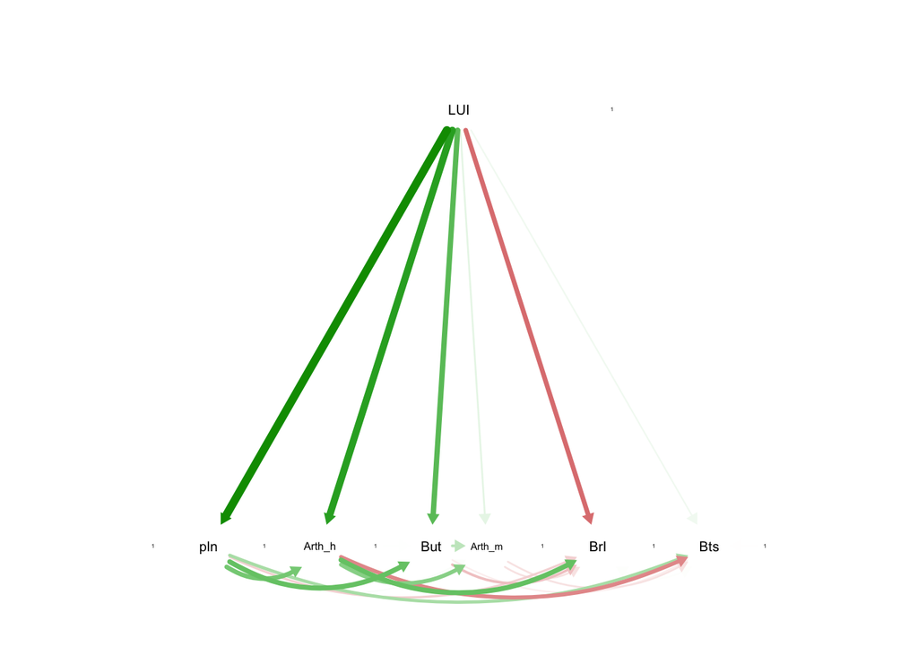

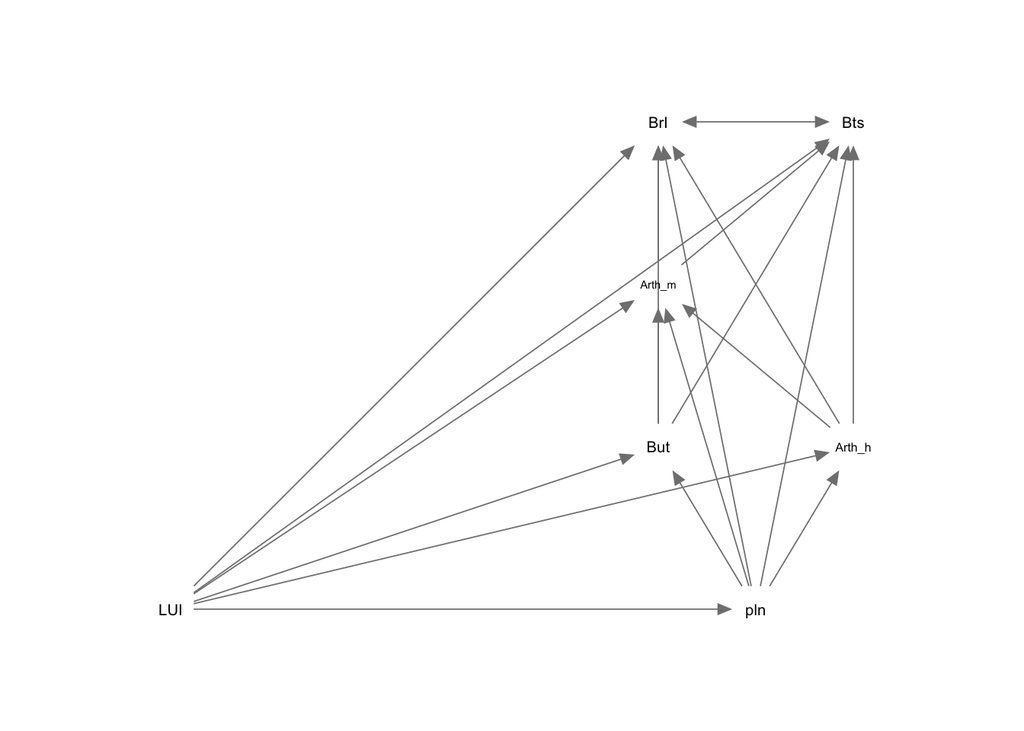

## Run below-ground model, simple

```
## lavaan 0.6-9 ended normally after 20 iterations
##
##   Estimator                                         ML
##   Optimization method                           NLMINB
##   Number of model parameters                        40
##
##                                                   Used       Total
##   Number of observations                           120         150
##
## Model Test User Model:
##
##   Test statistic                                12.602
##   Degrees of freedom                                 4
##   P-value (Chi-square)                           0.013
##
## Parameter Estimates:
##
##   Standard errors                             Standard
##   Information                                 Expected
##   Information saturated (h1) model          Structured
##
## Regressions:
##                          Estimate  Std.Err  z-value  P(>|z|)   Std.lv  Std.all
##   plant ~
##     LUI                     0.579    0.077    7.505    0.000    0.579    0.565
##   Protists_patho ~
##     LUI                     0.335    0.093    3.589    0.000    0.335    0.325
##     plant                   0.324    0.091    3.566    0.000    0.324    0.323
##   Microbes ~
##     LUI                     0.300    0.082    3.659    0.000    0.300    0.302
##     plant                   0.431    0.080    5.397    0.000    0.431    0.446
##   Protists_bact ~
##     LUI                     0.282    0.112    2.510    0.012    0.282    0.289
##     plant                   0.108    0.115    0.940    0.347    0.108    0.114
##     Microbes               -0.332    0.113   -2.925    0.003   -0.332   -0.337
##     Protists_patho          0.077    0.100    0.771    0.441    0.077    0.081
##   Protists_sec ~
##     LUI                     0.184    0.100    1.835    0.066    0.184    0.200
##     Protists_bact          -0.023    0.080   -0.288    0.773   -0.023   -0.024
##     plant                   0.158    0.101    1.570    0.116    0.158    0.176
```

[output cut: 19 more lines]

```
##     Coll                   -0.061    0.088   -0.697    0.486   -0.061   -0.063
##     Protists_sec           -0.076    0.107   -0.708    0.479   -0.076   -0.072
##     plant                  -0.061    0.113   -0.540    0.589   -0.061   -0.065
##     Protists_patho          0.030    0.104    0.292    0.771    0.030    0.032
##
## Variances:
##                    Estimate  Std.Err  z-value  P(>|z|)   Std.lv  Std.all
##    .plant             0.762    0.098    7.746    0.000    0.762    0.681
##    .Protists_patho    0.756    0.098    7.746    0.000    0.756    0.671
##    .Microbes          0.583    0.075    7.746    0.000    0.583    0.557
##    .Protists_bact     0.900    0.116    7.746    0.000    0.900    0.889
##    .Protists_sec      0.684    0.088    7.746    0.000    0.684    0.755
##    .Mites             0.931    0.120    7.746    0.000    0.931    0.910
##    .Coll              0.986    0.127    7.746    0.000    0.986    0.946
##    .Arth_mncrn_blw    0.958    0.124    7.746    0.000    0.958    0.962
```

```
## lavaan 0.6-9 ended normally after 23 iterations
##
##   Estimator                                         ML
##   Optimization method                           NLMINB
##   Number of model parameters                        37
##
##                                                   Used       Total
##   Number of observations                           120         150
##
## Model Test User Model:
##
##   Test statistic                                 5.971
##   Degrees of freedom                                 7
##   P-value (Chi-square)                           0.543
##
## Parameter Estimates:
##
##   Standard errors                             Standard
##   Information                                 Expected
##   Information saturated (h1) model          Structured
##
## Regressions:
##                          Estimate  Std.Err  z-value  P(>|z|)   Std.lv  Std.all
##   plant ~
##     LUI                     0.579    0.077    7.505    0.000    0.579    0.565
##   Protists_patho ~
##     LUI                     0.334    0.093    3.585    0.000    0.334    0.325
##     plant                   0.325    0.091    3.576    0.000    0.325    0.324
##   Microbes ~
##     LUI                     0.300    0.082    3.659    0.000    0.300    0.302
##     plant                   0.431    0.080    5.397    0.000    0.431    0.446
##   Protists_bact ~
##     LUI                     0.300    0.107    2.789    0.005    0.300    0.309
##     plant                   0.122    0.111    1.100    0.271    0.122    0.129
##     Microbes               -0.306    0.114   -2.689    0.007   -0.306   -0.312
##   Protists_sec ~
##     LUI                     0.194    0.097    2.005    0.045    0.194    0.210
##     plant                   0.166    0.097    1.707    0.088    0.166    0.184
##     Microbes                0.181    0.102    1.776    0.076    0.181    0.194
##     Protists_bact          -0.020    0.079   -0.257    0.797   -0.020   -0.021
```

[output cut: 20 more lines]

```
##                     Estimate  Std.Err  z-value  P(>|z|)   Std.lv  Std.all
##  .Protists_patho ~~
##    .Microbes           0.198    0.063    3.127    0.002    0.198    0.298
##    .Arth_mncrn_blw     0.017    0.074    0.226    0.821    0.017    0.020
##
## Variances:
##                    Estimate  Std.Err  z-value  P(>|z|)   Std.lv  Std.all
##    .plant             0.762    0.098    7.746    0.000    0.762    0.681
##    .Protists_patho    0.756    0.098    7.746    0.000    0.756    0.671
##    .Microbes          0.583    0.075    7.746    0.000    0.583    0.557
##    .Protists_bact     0.904    0.117    7.746    0.000    0.904    0.902
##    .Protists_sec      0.685    0.088    7.746    0.000    0.685    0.754
##    .Mites             0.957    0.124    7.746    0.000    0.957    0.949
##    .Coll              0.988    0.128    7.746    0.000    0.988    0.954
##    .Arth_mncrn_blw    0.960    0.124    7.746    0.000    0.960    0.963
```

```
##            cfi          rmsea rmsea.ci.upper            bic
##          1.000          0.000          0.102       2690.408
```

```
## [1] "Direct"
## [1] "Indirect"
## [1] "Total"
## [1] "Direct"
## [1] "Indirect"
## [1] "Total"
## [1] "Direct"
## [1] "Indirect"
## [1] "Total"
## [1] "Direct"
## [1] "Indirect"
## [1] "Total"
```

```
##            cfi          rmsea rmsea.ci.upper            bic
##          1.000          0.000          0.085       3236.381
```

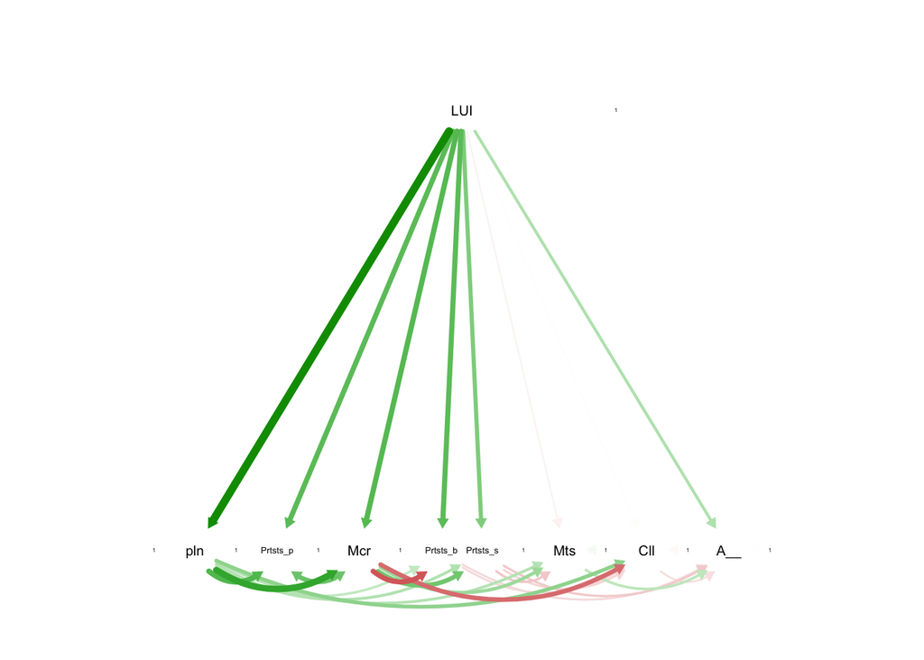

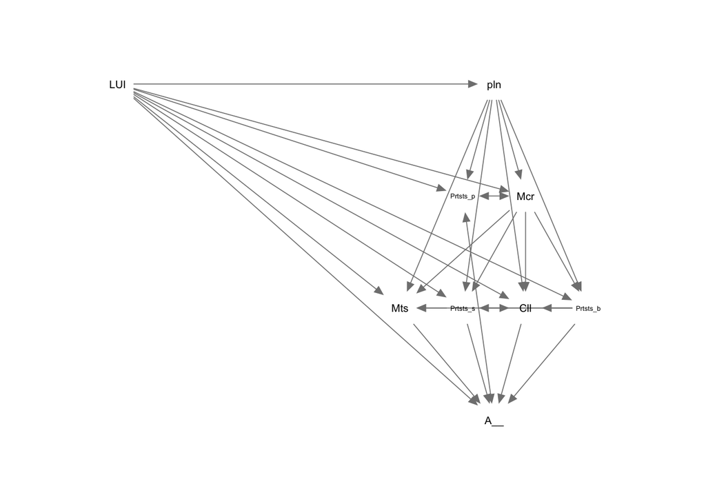

### Use the parameters defined in the simple SEM

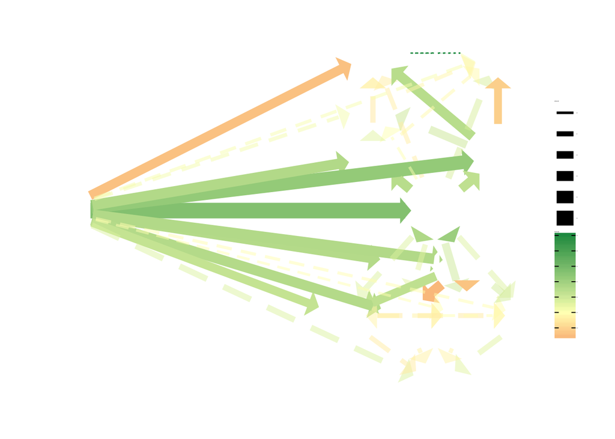

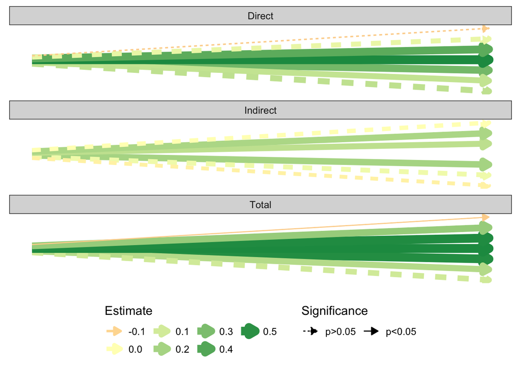

## Run above-ground model, full model

### Run below-ground model, full lui components

### Use the parameters defined in the complex SEMs

## get multidiv

```
## `set.seed(1)` was used to initialize repeatable random subsampling.
```

```
## Please record this for your records so others can reproduce.
```

```
## Try `set.seed(1); .Random.seed` for the full vector
```

```
## ...
```

```
## 50OTUs were removed because they are no longer
## present in any sample after random subsampling
```

```
## ...
```

```
## `set.seed(1)` was used to initialize repeatable random subsampling.
```

```
## Please record this for your records so others can reproduce.
```

```
## Try `set.seed(1); .Random.seed` for the full vector
```

```
## ...
```

```
## 11288OTUs were removed because they are no longer
## present in any sample after random subsampling
```

```
## ...
```

### Check effect on EF MF

```
## [1] 496
```

```
## [1] 496
```

| Plot | Dung.decomposition | Litter.decomposition | Root.decomposition | Biomass.production | Urease | DEA | Potential.nitrification | nifH | amoA_AOB | amoA_AOA | nxrA_NS | n16S_NB | beta_Glucosidase | N_Acetyl_beta_Glucosaminidase | Xylosidase | Phosphatase | Respiration |
| --- | --- | --- | --- | --- | --- | --- | --- | --- | --- | --- | --- | --- | --- | --- | --- | --- | --- |
| 0 | 0.05333333 | 0.006666667 | 0.08666667 | 0.05333333 | 0.03333333 | 0.01333333 | 0.01333333 | 0 | 0.006666667 | 0.006666667 | 0.006666667 | 0.006666667 | 0 | 0.02 | 0.01333333 | 0 | 0.02666667 |

```
##
##  Pearson's product-moment correlation
##
## data:  Axis1_all and Axis1_fun
## t = 10.808, df = 148, p-value < 2.2e-16
## alternative hypothesis: true correlation is not equal to 0
## 95 percent confidence interval:
##  0.5639307 0.7451180
## sample estimates:
##       cor
## 0.6641672
```

```
## Start:  AIC=-29.1
## Axis1_fun ~ Axis1_all
##
##             Df Sum of Sq    RSS     AIC
## <none>                   120.30 -29.095
## - Axis1_all  1    94.952 215.25  56.177
```

```
## Start:  AIC=9.93
## Axis1_fun ~ Dim.1_mic
##
##             Df Sum of Sq    RSS    AIC
## <none>                   156.05  9.929
## - Dim.1_mic  1    59.206 215.25 56.177
```

```
## Start:  AIC=10.72
## Axis1_fun ~ Dim.1_plants
##
##                Df Sum of Sq    RSS    AIC
## <none>                      156.88 10.725
## - Dim.1_plants  1    58.376 215.25 56.177
```

```
## Start:  AIC=34.56
## Axis1_fun ~ multidiv
##
##            Df Sum of Sq    RSS    AIC
## <none>                  183.90 34.563
## - multidiv  1    31.355 215.25 56.177
```

```
## Start:  AIC=-4.52
## Axis1_fun ~ LUI
##
##        Df Sum of Sq    RSS    AIC
## <none>              141.72 -4.517
## - LUI   1    73.533 215.25 56.177
```

```
##                                                Model Estimate (sd)
## 1   Functions slow-fast ~ entire community slow-fast   0.44 (0.04)
## 2             Functions slow-fast ~ plants slow-fast   0.35 (0.05)
## 3 Functions slow-fast ~ bacteria and fungi slow-fast  -0.44 (0.06)
## 4                          Functions slow-fast ~ LUI    0.7 (0.08)
## 5     Functions slow-fast ~ taxonomic multidiversity  -0.46 (0.09)
##                   Pval   R2        adj.P
## 1 1.95834612949108e-20 0.44 9.791731e-20
## 2 8.41769565406939e-12 0.27 1.052212e-11
## 3 5.64729436324433e-12 0.27 9.412157e-12
## 4 4.08910282693142e-15 0.34 1.022276e-14
## 5 1.44322458828257e-06 0.14 1.443225e-06
```

```
## lavaan 0.6-9 ended normally after 16 iterations
##
##   Estimator                                         ML
##   Optimization method                           NLMINB
##   Number of model parameters                         5
##
##   Number of observations                           150
##
## Model Test User Model:
##
##   Test statistic                                 0.000
##   Degrees of freedom                                 0
##
## Parameter Estimates:
##
##   Standard errors                            Bootstrap
##   Number of requested bootstrap draws             1000
##   Number of successful bootstrap draws            1000
##
## Regressions:
##                    Estimate  Std.Err  z-value  P(>|z|)
##   Axis1_fun ~
##     LUI        (d)    0.265    0.094    2.820    0.005
##     Axis1_all  (a)    0.333    0.053    6.267    0.000
##   Axis1_all ~
##     LUI        (b)    1.312    0.106   12.333    0.000
##
## Variances:
##                    Estimate  Std.Err  z-value  P(>|z|)
##    .Axis1_fun         0.768    0.108    7.098    0.000
##    .Axis1_all         1.590    0.181    8.775    0.000
##
## Defined Parameters:
##                    Estimate  Std.Err  z-value  P(>|z|)
##     indirect          0.437    0.079    5.506    0.000
##     total             0.703    0.069   10.213    0.000
##     diff              0.172    0.160    1.073    0.283
```

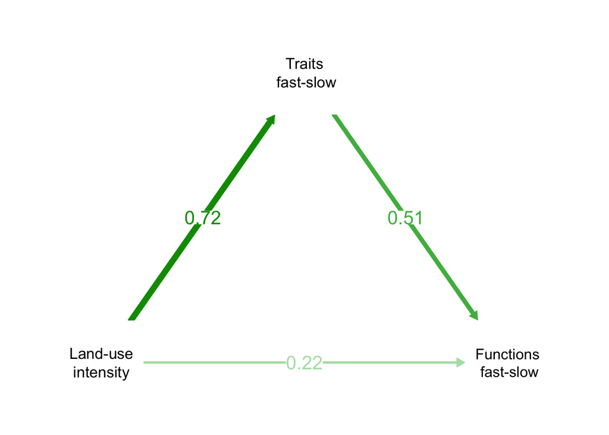